# HR Analytics with Kaggle

Alex Pitzer

December 26, 2016

# The Problem

In professional services industries, compensation can represent as much as 70% of an organization’s total expenses. As employees learn and grow within the company, they not only develop their own skills but also “tribal knowledge” - unique experience that is particularly valuable to the organization. If an employee leaves, he or she leaves a huge vacancy in tribal knowledge that is critical to the company’s success. Replacement costs aren’t just in recruiting fees - but also in training a new employee, lost productivity as a result of the vacancy, and the unquantifiable loss in specialized knowledge.

This makes employee retention absolutely critical to the success of an organization. If HR can predict why, how or when an employee is likely to leave an organization, it can take swift action to help mitigate these potential costs. Possible approaches include:

- Compensation adjustments for high-risk employees
- Additional training and development for high-value employees
- “Precognitive” recruiting for positions likely to be vacant

This analysis takes a dataset of $15,000$ employees and tries make predictions on whether or not an employee is likely to leave. HR departments could incorporate similar analyses into their compensation analyses to help address problems before they actualize. Please note that the some of the potential approaches listed above might be considered inequitable if not used appropriately.

# The Dataset

- Satisfaction level (from 0 to 1)
- Last evaluation (Assuming this is the last performance score)
- Number of projects (not certain what this corresponds to)
- Average monthly hours (160 is full time employment)
- Tenure (from 0 to infinity)
- Work accident (whether or not someone had an accident)
- Promotion in past 5 years ( 0 = No, 1 = Yes)
- Sales (the department of the employee)
- Salary (3 categories - low, medium, high)
- Left (whether or not an employee has actually left - used to develop predictions)

# Getting Started

Let’s read in the data.

```r
hr.df = read.csv('hr_analytics.csv', header = TRUE)
names(hr.df)
```

```
##  [1] "satisfaction_level"    "last_evaluation"
##  [3] "number_project"        "average_montly_hours"
##  [5] "time_spend_company"    "Work_accident"
##  [7] "left"                  "promotion_last_5years"
##  [9] "sales"                 "salary"
```

Let’s also see a summary of the dataset.

```r
summary(hr.df)
```

```
##  satisfaction_level last_evaluation number_project average_montly_hours
##  Min.   :0.090      Min.   :0.360   Min.   :2.0    Min.   : 96
##  1st Qu.:0.440      1st Qu.:0.560   1st Qu.:3.0    1st Qu.:156
##  Median :0.640      Median :0.720   Median :4.0    Median :200
##  Mean   :0.613      Mean   :0.716   Mean   :3.8    Mean   :201
##  3rd Qu.:0.820      3rd Qu.:0.870   3rd Qu.:5.0    3rd Qu.:245
##  Max.   :1.000      Max.   :1.000   Max.   :7.0    Max.   :310
##
##  time_spend_company Work_accident        left       promotion_last_5years
##  Min.   : 2.0       Min.   :0.000   Min.   :0.000   Min.   :0.0000
##  1st Qu.: 3.0       1st Qu.:0.000   1st Qu.:0.000   1st Qu.:0.0000
##  Median : 3.0       Median :0.000   Median :0.000   Median :0.0000
##  Mean   : 3.5       Mean   :0.145   Mean   :0.238   Mean   :0.0213
##  3rd Qu.: 4.0       3rd Qu.:0.000   3rd Qu.:0.000   3rd Qu.:0.0000
##  Max.   :10.0       Max.   :1.000   Max.   :1.000   Max.   :1.0000
##
##          sales         salary
##  sales      :4140   high  :1237
##  technical  :2720   low   :7316
##  support    :2229   medium:6446
##  IT         :1227
##  product_mng: 902
##  marketing  : 858
##  (Other)    :2923
```

Interesting is that the tenure variable (**time_spent_company**) has such low mean and medians, and that so few people have been promoted in the past five years. The might suggest the company is relatively new. This company also has an average workmonth of about 200 hours - which is approximately a 50 hour workweek. That’s surprising, considering so many of the employees are in the technical, support or IT departments.

# Data processing

Some of these variables report categorical information - such as the sales (department) and the salary variables. We should generate new features for each of the values of the categorical variables.

```r
# Create salary dummies
hr.df = cbind(hr.df, dummy(hr.df$salary ))
# remove salary var
hr.df$salary = NULL
hr.df$hr.dfmedium = NULL
# also remove medium salary variable for linear algebra reasons


# Create sales (dept) dummies
hr.df = cbind(hr.df, dummy(hr.df$sales))
# Remove dftechnical column for linear algebra reasons
names(hr.df) = c("satisfaction_level", "last_evaluation", "number_project", "average_montly_hours",
                 "time_spend_company", "Work_accident", "left", "promotion_last_5years", 'sales',
                 'hr.dfhigh', 'hr.dflow', 'hr.dfmedium', 'hr.dfaccounting', 'hr.dfhr',
                 'hr.dfIT', 'hr.dfmanagement', 'hr.dfmarketing', 'hr.dfproduct_mng',
                 'hr.dfRandD', 'hr.dfsales', 'hr.dfsupport', 'hr.dftechnical')

hr.df$sales = NULL
hr.df$hr.dftechnical = NULL
```

# Feature Generation

Now we create some variables using intuition about HR. There are a few things that might cause an employee to quit - job satisfaction, pay, number of hours, and tenure. Part time employees (less than say, 75% full time) may not feel tied to the organization, and employees spending lots of time at work may suffer from burnout. Alternatively, these employees may be the most dedicated - maybe a combination of hours worked and job satisfaction is a good predictor of whether an employee leaves or not.

The first step is doing some binarization - cutting up our data into different True/False categories, following our nose on what factors might translate into an employee leaving.

## Simple Binary Feature Generation

Here I define some simple binary features (True or False) based on one variable in our dataset.

The first two variables record whether or not someone works part time or too much, in relation to the median.

```r
part.time.cutoff = min(median(hr.df$average_montly_hours) * .75, 140)
overworked.cutoff = median(hr.df$average_montly_hours) * 1.25
hr.df$part.time = hr.df$average_montly_hours < part.time.cutoff
hr.df$overworked = hr.df$average_montly_hours >  overworked.cutoff
```

I also add in variables to record whether someone is high tenure or low tenure, based on the first and third quartiles of tenure.

```r
hr.df$low.tenure = hr.df$time_spend_company < quantile(hr.df$time_spend_company, .25)[[1]]
hr.df$high.tenure = hr.df$time_spend_company > quantile(hr.df$time_spend_company, .75)[[1]]
```

Also I create some variables to record people that are highly satified with their work (above .8 in sastifaction) and people highly unsatisfied (below .3).

```r
hr.df$low.satisfaction = hr.df$satisfaction_level < .3
hr.df$high.satisfaction = hr.df$satisfaction_level > .8
```

Similarly I define binary variables to categorize individuals who were rated very well or very poorly in their last evaluation.

```r
hr.df$low.evaluation = hr.df$last_evaluation < quantile(hr.df$last_evaluation, .25)[[1]]
hr.df$high.evaluation = hr.df$last_evaluation > quantile(hr.df$last_evaluation, .75)[[1]]
```

## Binary Variables Based on Multiple Features

Now I use combinations of binary variables to define further binary variables. These combinations may be excellent for predicting if an employee is going to leave, one such example may be low salary *x* overworked.

First up is identifying combinations of the salary vars vis-a-vis the other binary variables.

```r
salary.vars = c("hr.dfhigh", 'hr.dflow')
salary.combo.vars = c("part.time", "overworked", "low.tenure",
                      "high.tenure", "low.satisfaction", "high.satisfaction",
                      "low.evaluation", "high.evaluation")

for (sal.var in salary.vars) {
  for(s.combo in salary.combo.vars) {
    name = paste(sal.var, s.combo, sep = "_x_")
    hr.df[name] = hr.df[[sal.var]] * hr.df[[s.combo]]
  }
}
```

Let’s also create binary product variables using job satisfaction, salary and last_evaluation in relation to the various departments.

```r
dept.vars = c("hr.dfaccounting", 'hr.dfhr', 'hr.dfIT', 'hr.dfmanagement', 'hr.dfmarketing',
              'hr.dfproduct_mng', 'hr.dfRandD', 'hr.dfsales', 'hr.dfsupport')
dept.combo.vars = c("low.satisfaction", 'high.satisfaction', 'low.evaluation', 'high.evaluation',
                    'hr.dflow', 'hr.dfhigh')

for(dv in dept.vars){
  for(dpcomb in dept.combo.vars){
    name = paste(dv, dpcomb, sep = "_x_")
    hr.df[name] = hr.df[[dv]] * hr.df[[dpcomb]]
  }
}
```

This completes the “first tour” of binary feature generation.

## Visual Analysis of Numeric Variables

Let’s step back a minute and look at some of our numeric variables, such as tenure, performance evaluation and satisfaction_level. We look at these variables standalone first.

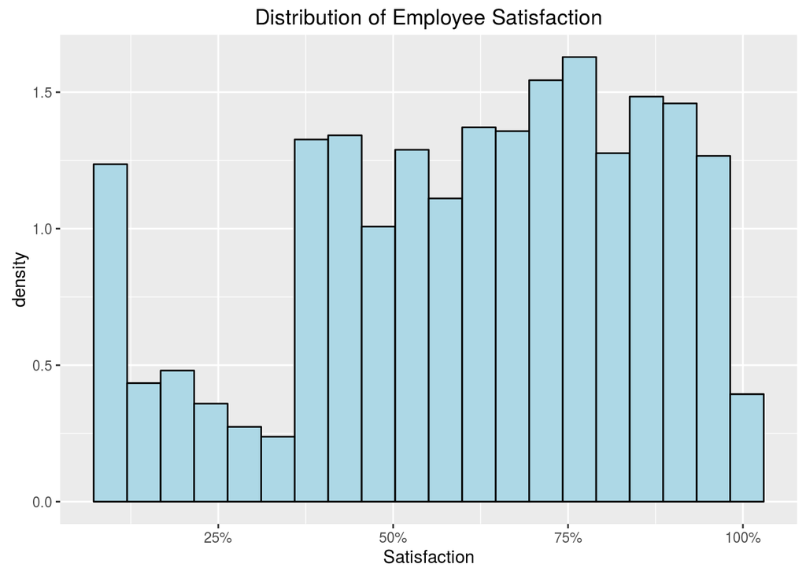

```r
ggplot(hr.df, aes(satisfaction_level, y = ..density..)) +
  geom_histogram(bins = 20, fill = 'lightblue', color = 'black') +
  scale_x_continuous(labels = scales::percent_format()) +
  labs(x = "Satisfaction", title = "Distribution of Employee Satisfaction")
```

There appears to be a few modes to this data. There is a significant number of employees with exceedingly low satisfaction scores - less than 10%. These people may be highly likely to vacate their roles. There are generally pretty few employees with 10% to 35% satisfaction. Then there is a bulk of employees with a bit less than 50% satisfaction - employees who may not like their roles, but might be salvageable. The rest of the distribution looks relatively uniform, with a peak at about 75% to 80% job satisfaction.

Let’s see how job satisfaction is distributed, broken down by employees who left.

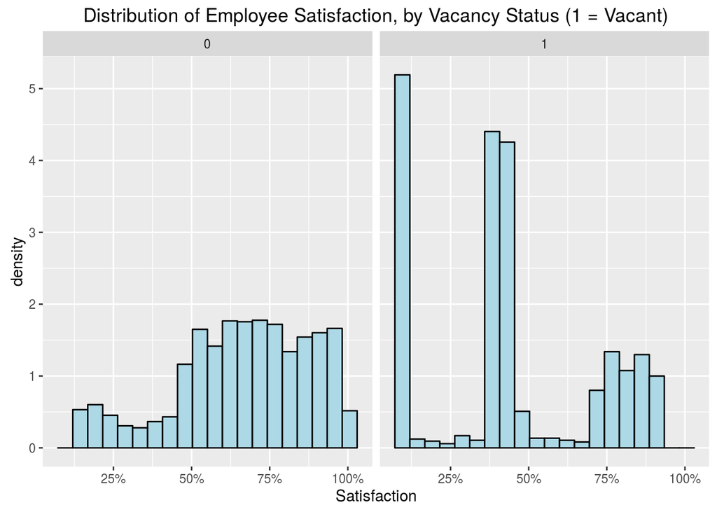

```r
ggplot(hr.df, aes(satisfaction_level, y = ..density..)) +
  geom_histogram(bins = 20, fill = 'lightblue', color = 'black') +
  scale_x_continuous(labels = scales::percent_format()) +
  labs(x = "Satisfaction", title = "Distribution of Employee Satisfaction, by Vacancy Status (1 = Vacant)") +
  facet_wrap(~left)
```

The intuition appears correct - high leave rates seem to come from the two modes discussed earlier. Let’s create another binary variable for employees with job satisfaction in the 30% to 50% range.

```r
hr.df$med.satisfaction = hr.df$satisfaction_level > .3 && hr.df$satisfaction_level < .5
```

Next, let’s look at distribution of tenure and how it relates to job leave.

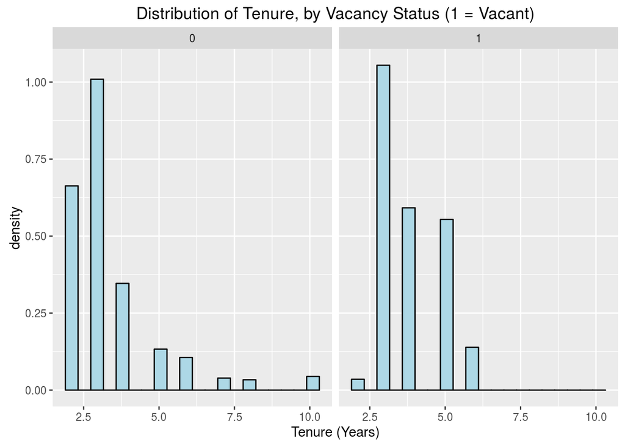

```r
ggplot(hr.df, aes(time_spend_company, y = ..density..)) +
  geom_histogram(bins = 20, fill = 'lightblue', color = 'black') +
  labs(x = "Tenure (Years)", title = "Distribution of Tenure, by Vacancy Status (1 = Vacant)") +
  facet_wrap(~left)
```

```r
hr.df$med.tenure = hr.df$time_spend_company > 4.5 && hr.df$time_spend_company < 5.5
```

Next - the distribution of last evaluation by leave.

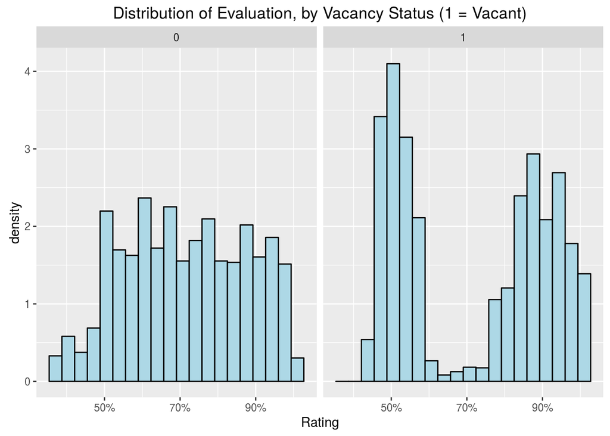

```r
ggplot(hr.df, aes(last_evaluation, y = ..density..)) +
  geom_histogram(bins = 20, fill = 'lightblue', color = 'black') +
  labs(x = "Rating", title = "Distribution of Evaluation, by Vacancy Status (1 = Vacant)") +
  scale_x_continuous(labels = scales::percent_format()) +
  facet_wrap(~left)
```

The distribution for people who are not leaving looks pretty uniform - but it looks like the highest and lowest evaluated employees are the ones leaving.

Let’s try to identify trends in the number of projects.

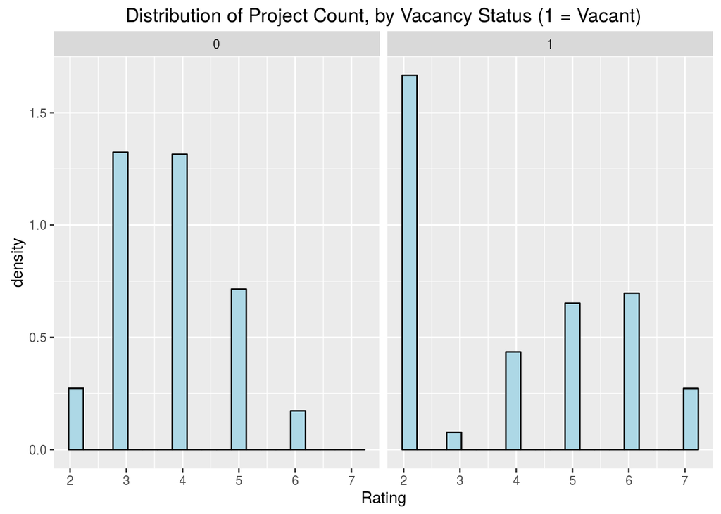

```r
ggplot(hr.df, aes(number_project, y = ..density..)) +
  geom_histogram(bins = 20, fill = 'lightblue', color = 'black') +
  labs(x = "Rating", title = "Distribution of Project Count, by Vacancy Status (1 = Vacant)") +
  facet_wrap(~left)
```

It appears highly utilized and highly underutilized employees are the most likely to leave. This begs two more binary variables.

```r
hr.df$underutlized = hr.df$number_project < 3
hr.df$overutilized = hr.df$number_project > 4
```

Now we look at monthly utilization to see how hours worked contributes to people leaving.

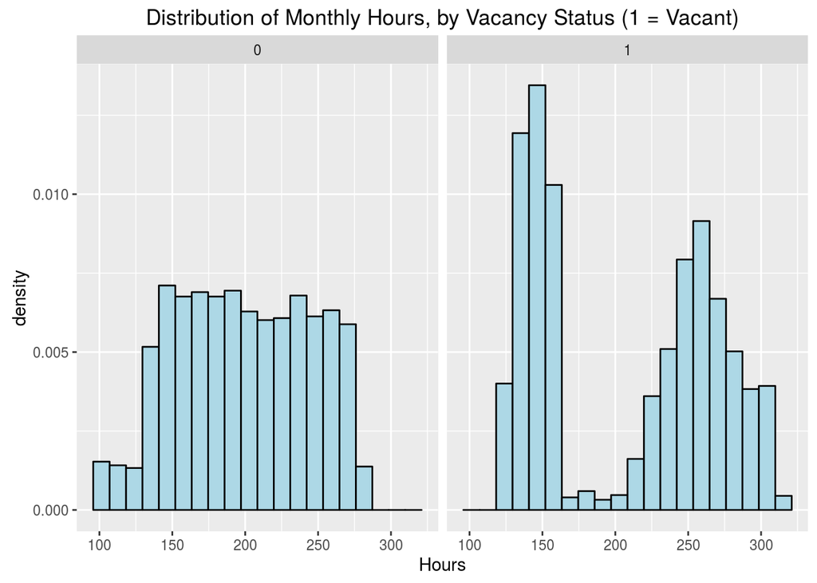

```r
ggplot(hr.df, aes(average_montly_hours, y = ..density..)) +
  geom_histogram(bins = 20, fill = 'lightblue', color = 'black') +
  labs(x = "Hours", title = "Distribution of Monthly Hours, by Vacancy Status (1 = Vacant)") +
  facet_wrap(~left)
```

The already defined binary variables should be sufficient to capture how monthly worktime relates to vacancies.

## Power Transforms

I generate power transforms for some of these variables. This should aid in linear separability for some variables, where either a low or a high value of the variable is a good indicator for someone leaving (as for the project count). I **square** these variables - but note that performance may be better for other transformations. I doubt that using logarithms or square root transforms will help in this case - but what may help is a deviation from the mean.

```r
eligible.power.vars = c("satisfaction_level", "last_evaluation", "number_project",
                        "average_montly_hours", "time_spend_company")
for(var in eligible.power.vars) {
  name = paste(var, "squared", sep=".")
  hr.df[name]  = hr.df[var] ^ 2
}
```

## Other Numeric Transforms

I add variables recording deviation from the mean for the following features:

- satistfaction_level
- last_evaluation
- monthly_hours

```r
for (v in c("satisfaction_level", "last_evaluation", "average_montly_hours")) {
 name = paste(v, "dev.from.mean", sep = ".")
   hr.df[name] = abs(hr.df[[v]] - mean(hr.df[[v]]))
}
```

# Predictive Modeling

I use a LASSO logistic regularization model to predict whether or not someone is going to leave, using the dataset above.

```r
hr.df = hr.df[complete.cases(hr.df), ]
y = data.matrix(hr.df$left)
X = data.matrix(select(hr.df, -left))
model = cv.glmnet(X, y, family = "binomial", alpha = 1, type.measure = "class")
```

This model is a cross-validated LASSO logistic regression model with no Ridge parameterization. Now we evaluate model quality, using a confusion matrix.

```r
predictions = round(predict(model, X, type = 'response'))
confusionMatrix(predictions, y)
```

```
## Confusion Matrix and Statistics
##
##           Reference
## Prediction     0     1
##          0 10865   471
##          1   563  3100
##
##                Accuracy : 0.931
##                  95% CI : (0.927, 0.935)
##     No Information Rate : 0.762
##     P-Value [Acc > NIR] : < 2e-16
##
##                   Kappa : 0.812
##  Mcnemar's Test P-Value : 0.00466
##
##             Sensitivity : 0.951
##             Specificity : 0.868
##          Pos Pred Value : 0.958
##          Neg Pred Value : 0.846
##              Prevalence : 0.762
##          Detection Rate : 0.724
##    Detection Prevalence : 0.756
##       Balanced Accuracy : 0.909
##
##        'Positive' Class : 0
##
```